# Red wine quality - an Explorative Data Analysis

by Stefanie Powazny

========================================================

## Introduction to the dataset

The aim of this project is to investigate a dataset of red wines to reveal what properties influence the quality of the wine.

### Dimension of the dataset

```
## [1] 1599   13
```

### Structure of the dataset

```
## 'data.frame':    1599 obs. of  13 variables:
##  $ X                   : int  1 2 3 4 5 6 7 8 9 10 ...
##  $ fixed.acidity       : num  7.4 7.8 7.8 11.2 7.4 7.4 7.9 7.3 7.8 7.5 ...
##  $ volatile.acidity    : num  0.7 0.88 0.76 0.28 0.7 0.66 0.6 0.65 0.58 0.5 ...
##  $ citric.acid         : num  0 0 0.04 0.56 0 0 0.06 0 0.02 0.36 ...
##  $ residual.sugar      : num  1.9 2.6 2.3 1.9 1.9 1.8 1.6 1.2 2 6.1 ...
##  $ chlorides           : num  0.076 0.098 0.092 0.075 0.076 0.075 0.069 0.065 0.073 0.071 ...
##  $ free.sulfur.dioxide : num  11 25 15 17 11 13 15 15 9 17 ...
##  $ total.sulfur.dioxide: num  34 67 54 60 34 40 59 21 18 102 ...
##  $ density             : num  0.998 0.997 0.997 0.998 0.998 ...
##  $ pH                  : num  3.51 3.2 3.26 3.16 3.51 3.51 3.3 3.39 3.36 3.35 ...
##  $ sulphates           : num  0.56 0.68 0.65 0.58 0.56 0.56 0.46 0.47 0.57 0.8 ...
##  $ alcohol             : num  9.4 9.8 9.8 9.8 9.4 9.4 9.4 10 9.5 10.5 ...
##  $ quality             : int  5 5 5 6 5 5 5 7 7 5 ...
```

> This dataset contains information about 1599 red wines regarding 13 variables such as their quality and physicochemical properties, i.e. their pH and alcohol content in % by volume. Further variables are: fixed acidity (tartaric acid - g / dm^3) volatile acidity (acetic acid - g / dm^3) citric acid (g / dm^3) residual sugar (g / dm^3) chlorides (sodium chloride - g / dm^3) total and free sulfur dioxide (mg / dm^3) density (g / cm^3) sulphates (potassium sulphate - g / dm^3) The quality was assesed through at least 3 experts who graded the wine quality between 0 (very bad) and 10 (very excellent). The median of these ratings was computed as the wine quality. The 13th variable X resembels the red wine itself.

```r
# Convert quality int to factor type for later investigations
df$quality <- factor(df$quality, ordered = T)
```

## Univariate Plots Section

I start with a first look at the structure of the properties in this dataset by investigating the dataset summary and by using histograms.

### Summary of the dataset

```
##        X          fixed.acidity   volatile.acidity  citric.acid
##  Min.   :   1.0   Min.   : 4.60   Min.   :0.1200   Min.   :0.000
##  1st Qu.: 400.5   1st Qu.: 7.10   1st Qu.:0.3900   1st Qu.:0.090
##  Median : 800.0   Median : 7.90   Median :0.5200   Median :0.260
##  Mean   : 800.0   Mean   : 8.32   Mean   :0.5278   Mean   :0.271
##  3rd Qu.:1199.5   3rd Qu.: 9.20   3rd Qu.:0.6400   3rd Qu.:0.420
##  Max.   :1599.0   Max.   :15.90   Max.   :1.5800   Max.   :1.000
##  residual.sugar     chlorides       free.sulfur.dioxide
##  Min.   : 0.900   Min.   :0.01200   Min.   : 1.00
##  1st Qu.: 1.900   1st Qu.:0.07000   1st Qu.: 7.00
##  Median : 2.200   Median :0.07900   Median :14.00
##  Mean   : 2.539   Mean   :0.08747   Mean   :15.87
##  3rd Qu.: 2.600   3rd Qu.:0.09000   3rd Qu.:21.00
##  Max.   :15.500   Max.   :0.61100   Max.   :72.00
##  total.sulfur.dioxide    density             pH          sulphates
##  Min.   :  6.00       Min.   :0.9901   Min.   :2.740   Min.   :0.3300
##  1st Qu.: 22.00       1st Qu.:0.9956   1st Qu.:3.210   1st Qu.:0.5500
##  Median : 38.00       Median :0.9968   Median :3.310   Median :0.6200
##  Mean   : 46.47       Mean   :0.9967   Mean   :3.311   Mean   :0.6581
##  3rd Qu.: 62.00       3rd Qu.:0.9978   3rd Qu.:3.400   3rd Qu.:0.7300
##  Max.   :289.00       Max.   :1.0037   Max.   :4.010   Max.   :2.0000
##     alcohol      quality
##  Min.   : 8.40   3: 10
##  1st Qu.: 9.50   4: 53
##  Median :10.20   5:681
##  Mean   :10.42   6:638
##  3rd Qu.:11.10   7:199
##  Max.   :14.90   8: 18
```

> For some properties (i.e., residual sugar, total sulfur dioxide) the maximum value is far beyond the third quantile which indicates that their distribution does not follow a normal distribution. Histograms will help to visualize the distribution of the properties.

### Histograms - a quick overview

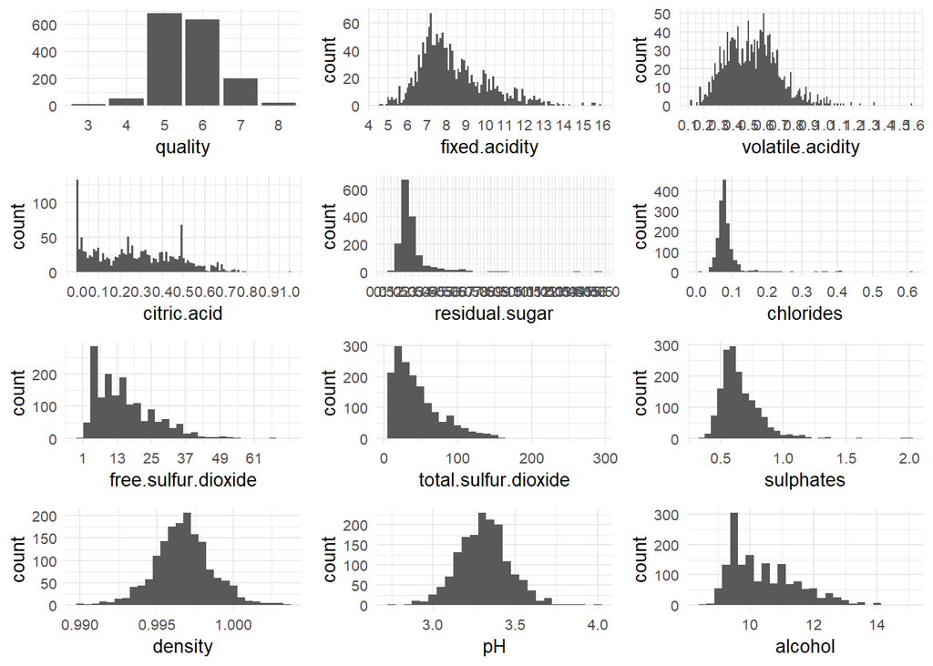

> The quality rating of each expert could range between 1 and 10. It appears that the median of the three expert ratings only ranged from 3 to 8 while most wines quality is 5 or 6. Therefore, I will create a new variable with three quality categories: low (3,4), medium (5,6) and high (7,8) quality.

> Some variables show a “long tail”: fixed.acidity,volatile.acidity, citric.acid, residual.sugar, chlorides, free.sulfur.dioxide, total.sulfur.dioxide, sulphates and alcohol. The hitograms of these variables are skewed to the right. I will apply a log10 transformation to these variables and remove outliers from plotting to improve the plots. The variables density and pH will not be transformed as they look normally distributed and do not contain distracting outliers.

### Quality - categorized

```r
# Categorize quality into 3 levels
df$quality.cat <- ifelse(df$quality < 5, 'low',
                         ifelse(df$quality < 7, 'medium',
                                'high'))

# Change the new variable quality.cat into an ordered factor
df$quality.cat <- ordered(df$quality.cat,
                          levels = c('low', 'medium', 'high'))
```

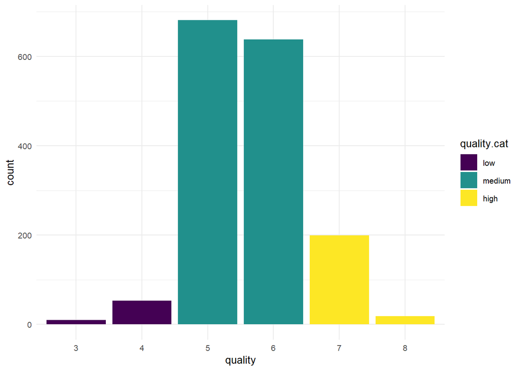

> The most wines got a medium quality rating (quality 5 to 6). The minority got a low rating. The best and the least quality (3 and 8) were at least assigned.

### Fixed acidity - log10 transformed

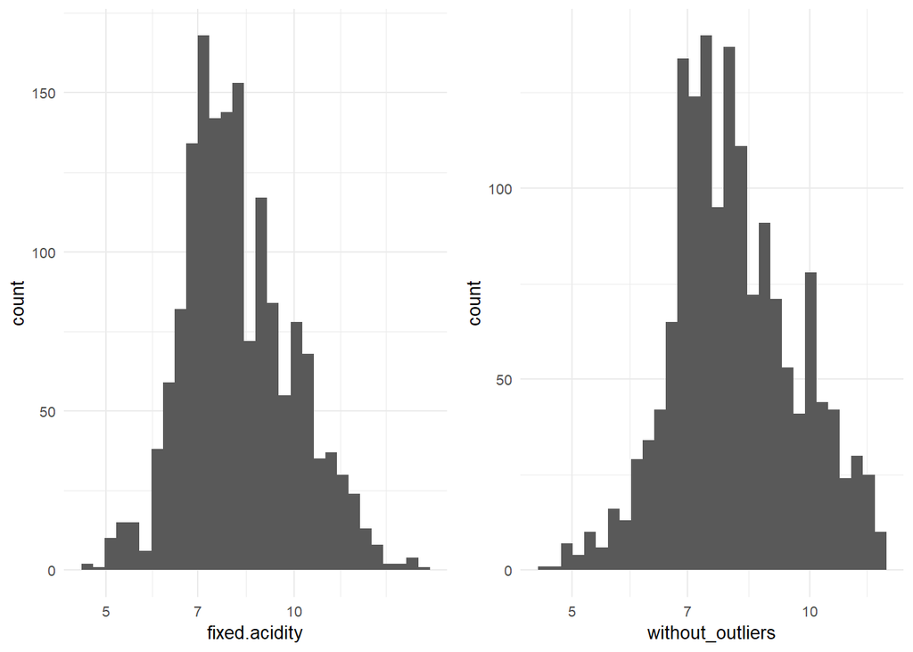

```
##    Min. 1st Qu.  Median    Mean 3rd Qu.    Max.
##    4.60    7.10    7.90    8.32    9.20   15.90
```

### Volatile acidity - log10 transformed

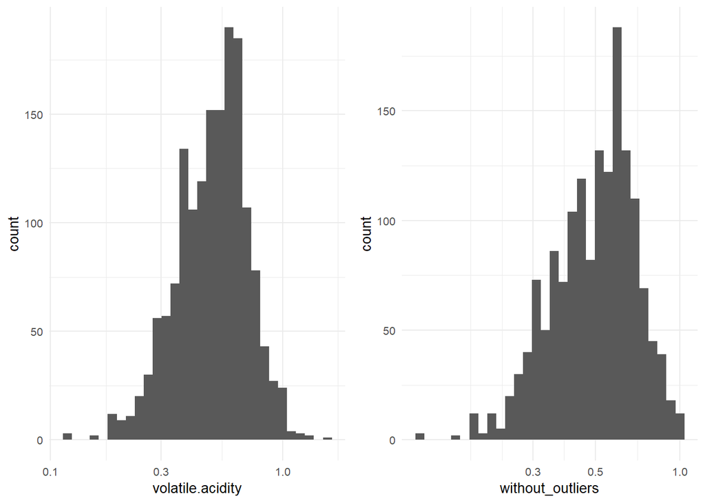

```
##    Min. 1st Qu.  Median    Mean 3rd Qu.    Max.
##  0.1200  0.3900  0.5200  0.5278  0.6400  1.5800
```

### Citric acid - log10 transformed

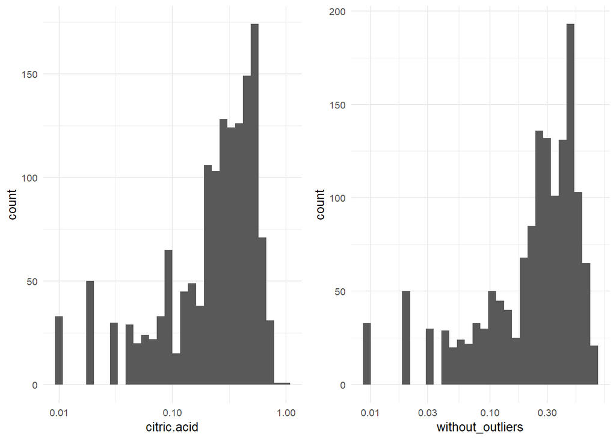

```
##    Min. 1st Qu.  Median    Mean 3rd Qu.    Max.
##   0.000   0.090   0.260   0.271   0.420   1.000
```

> Citric acid does not follow a normal distribution on a logarithmic scale. There are 132 observations with a value of zero. Without the outliers it is easier to see the peak of the distribution. It is about 0,39 g / dm^3.

### Residual sugar - log10 transformed

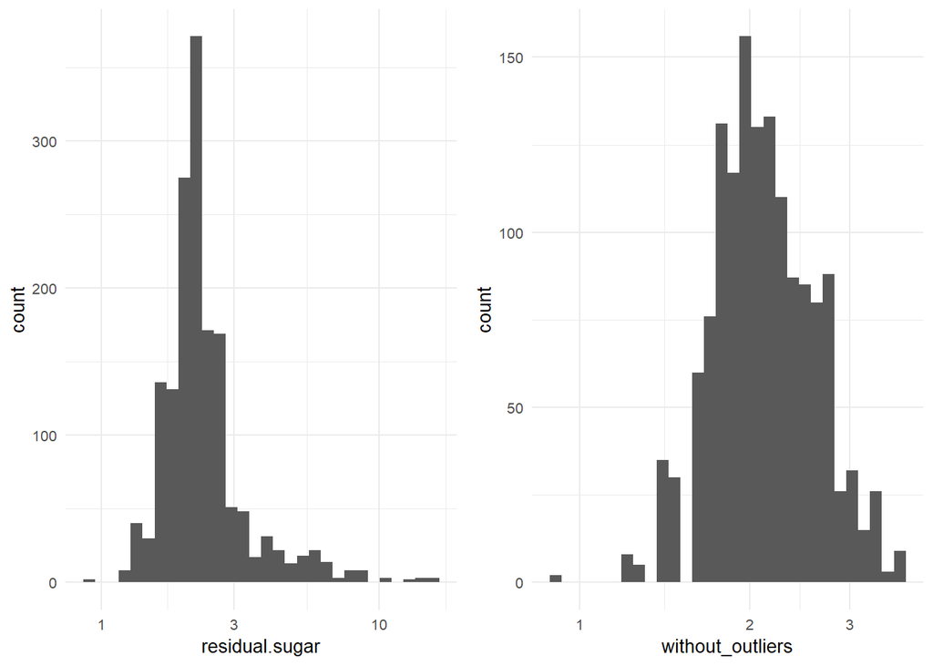

```
##    Min. 1st Qu.  Median    Mean 3rd Qu.    Max.
##   0.900   1.900   2.200   2.539   2.600  15.500
```

### Chlorides - log10 transformed

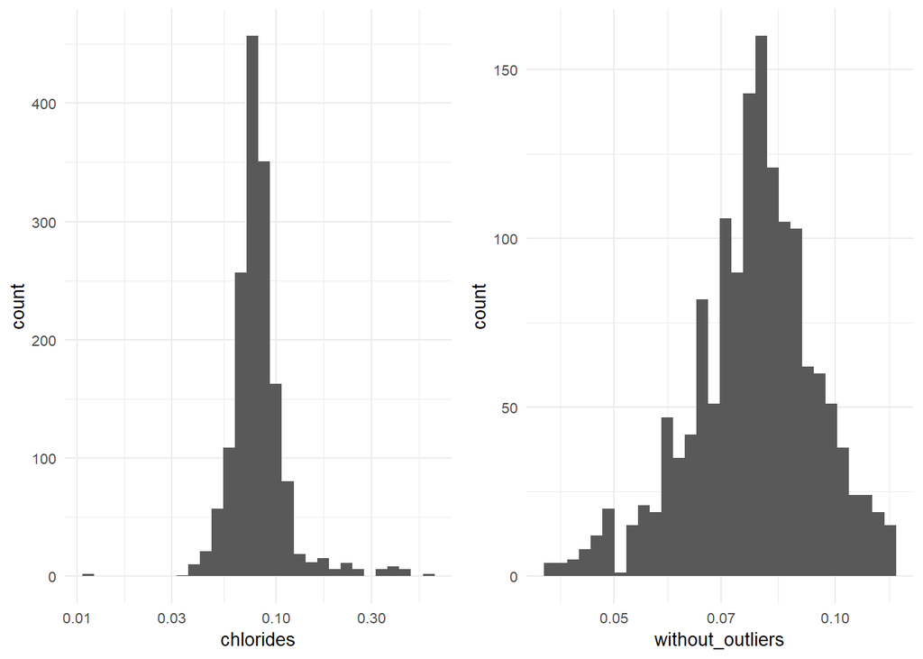

```
##    Min. 1st Qu.  Median    Mean 3rd Qu.    Max.
## 0.01200 0.07000 0.07900 0.08747 0.09000 0.61100
```

> Now, the data looks normally distributed. The peak of the distribution is about 0,0778 g / dm^3.

### Free sulfur dioxide - log10 transformed

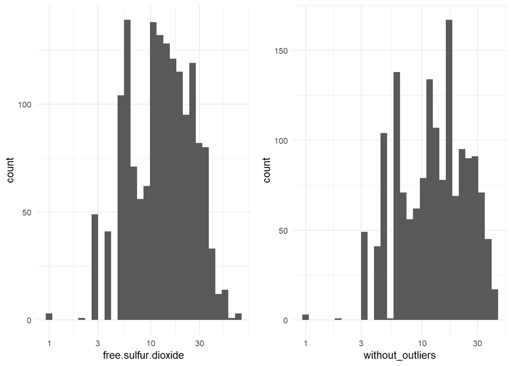

```
##    Min. 1st Qu.  Median    Mean 3rd Qu.    Max.
##    1.00    7.00   14.00   15.87   21.00   72.00
```

> Now, the data roughly looks normally distributed. Without the outliers it is easier to see the peak of the distribution. It is about 19 mg / dm^3.

### Total sulfur dioxide - log10 transformed

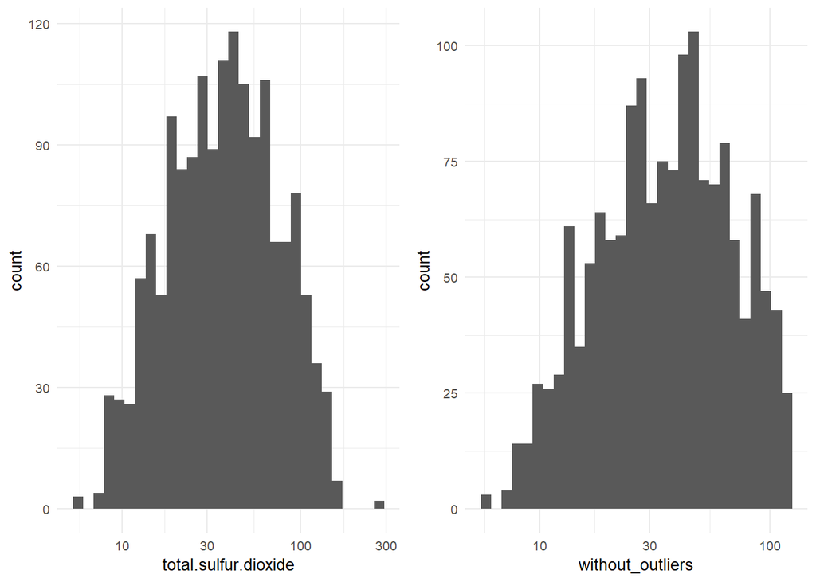

```
##    Min. 1st Qu.  Median    Mean 3rd Qu.    Max.
##    6.00   22.00   38.00   46.47   62.00  289.00
```

### Sulphates - log10 transformed

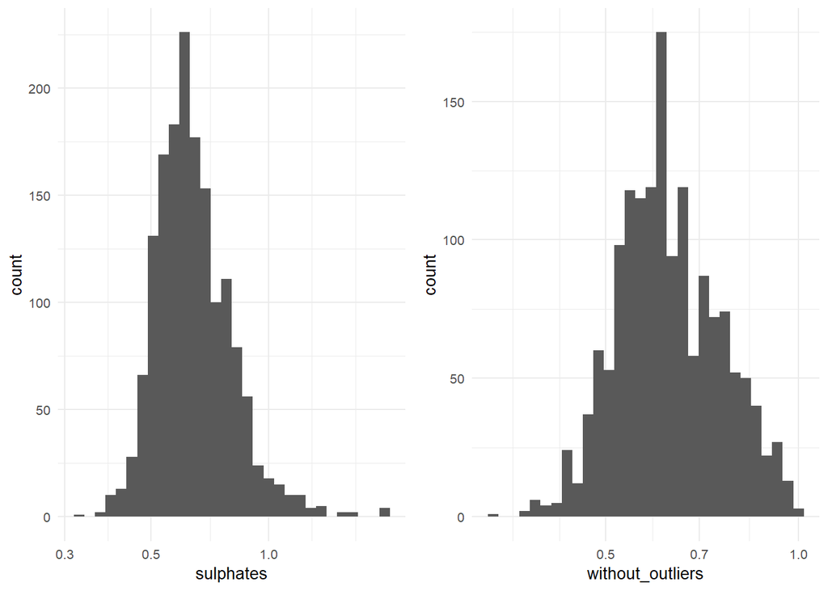

```
##    Min. 1st Qu.  Median    Mean 3rd Qu.    Max.
##  0.3300  0.5500  0.6200  0.6581  0.7300  2.0000
```

> Now, the data looks normally distributed. Without the outliers it is easier to see the peak of the distribution. It is about 0,62 g / dm^3.

### Alcohol - log10 transformed

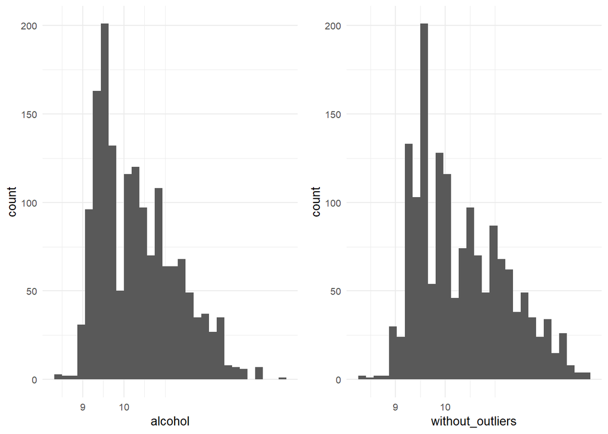

```
##    Min. 1st Qu.  Median    Mean 3rd Qu.    Max.
##    8.40    9.50   10.20   10.42   11.10   14.90
```

> Now, the data roughly looks normally distributed. Without the outliers it is easier to see the peak of the distribution. It is about 9,6 % per volume.

## Univariate Analysis

### What is the structure of your dataset?

> This dataset includes 1599 red wine observations and 11 variables, regarding their physical and chemical properties and 1 variable regarding their rated quality by three experts. None of these variables has missing values.

### What is/are the main feature(s) of interest in your dataset?

> I consider the quality as the main feature of interest as it is interesting to see what physicial and chemical proberties of red wines do influence the subjective quality rating which I would consider as an important purchase reason. I think alcohol, residual sugar and pH are interesting properties to look at as they should influence the taste of the wine.

### What other features in the dataset do you think will help support your investigation into your feature(s) of interest?

> Sulphates and density could support my investigation.

### Did you create any new variables from existing variables in the dataset?

> I created a new categorial variable to categorize the wines into three quality categories (low, medium, high) according to their quality rating.

### Of the features you investigated, were there any unusual distributions? Did you perform any operations on the data to tidy, adjust, or change the form of the data? If so, why did you do this?

> The variables pH and density were normally distributed with less outliers. Thus, I did not perform any operations on these properties. To reduce the skewness of the other properties, I applied log10 transformations on them and omitted outliers. This allowed me to focus on the main data points and to facilitate the investigation of the most common values. Citric acid did not follow a normal distribution on a logarithmic scale.

## Bivariate Plots Section

In this section, I will analyse relationships between wine properties and the wine quality. Furthermore, I will investigate relationships between different wine properties.

### Correlation matrix

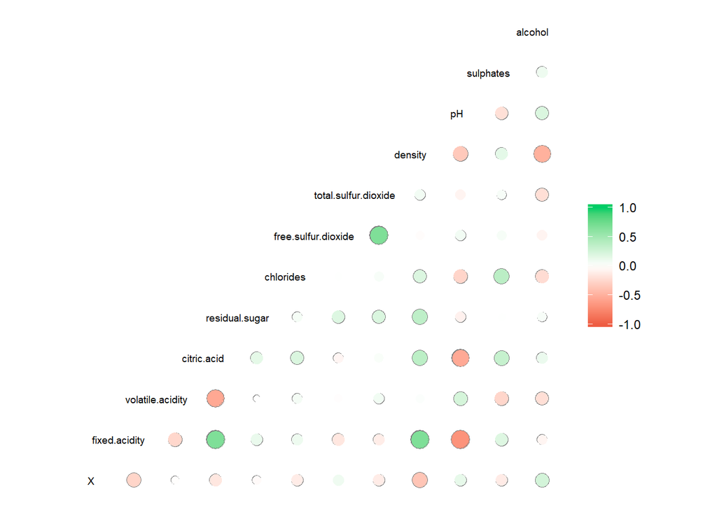

> First, I look at a correlation matrix to explore the relationships between the various wine properties There are some strong positive relationships: fixed.acidity and citric.acid, fixed.acidity and density, free.sulfur.dioxide and total.sulfur.dioxide, as well as some strong to moderate negative relationships: fixed.acidity and pH, volatile.acidity and citric.acid, citric.acid and pH, density and alcohol

### Boxplots

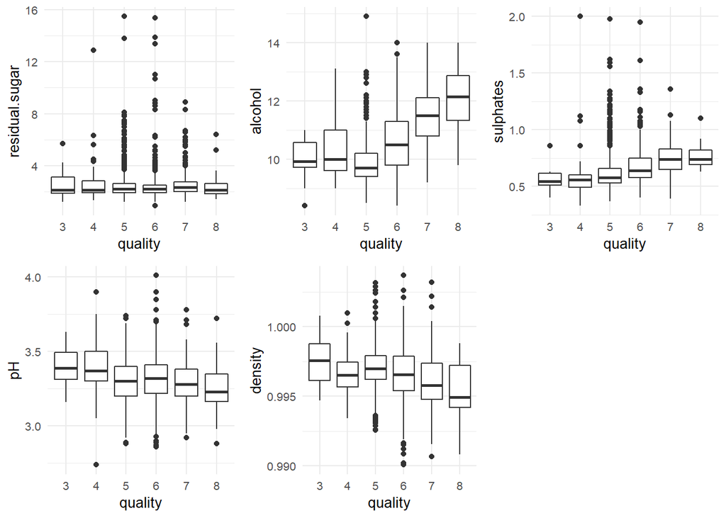

> I will create these boxplots without outliers in the next step to enhance the plots.

### Boxplots - without outliers

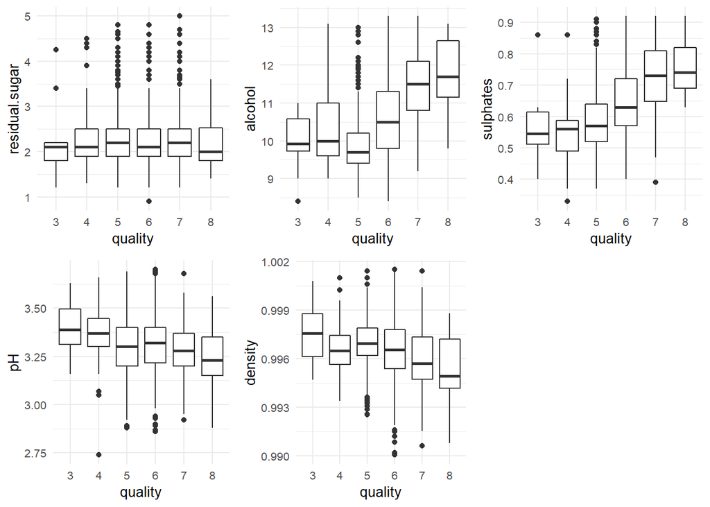

As mentioned above I will dive in deeper into the relationship between the quality and some physicial and chemical properties of the wine.

### Residual sugar and quality

```r
# Get the median of residual sugar to split it into 2 categories
# (high and low) using min, median and max, and omit outliers to
# concentrate on the bulk of the data
summary(df$residual.sugar)
```

```
##    Min. 1st Qu.  Median    Mean 3rd Qu.    Max.
##   0.900   1.900   2.200   2.539   2.600  15.500
```

```r
# median = 2.2
df$residual.sugar.bucket <- cut(df$residual.sugar, c(0,2.2,15.5))
```

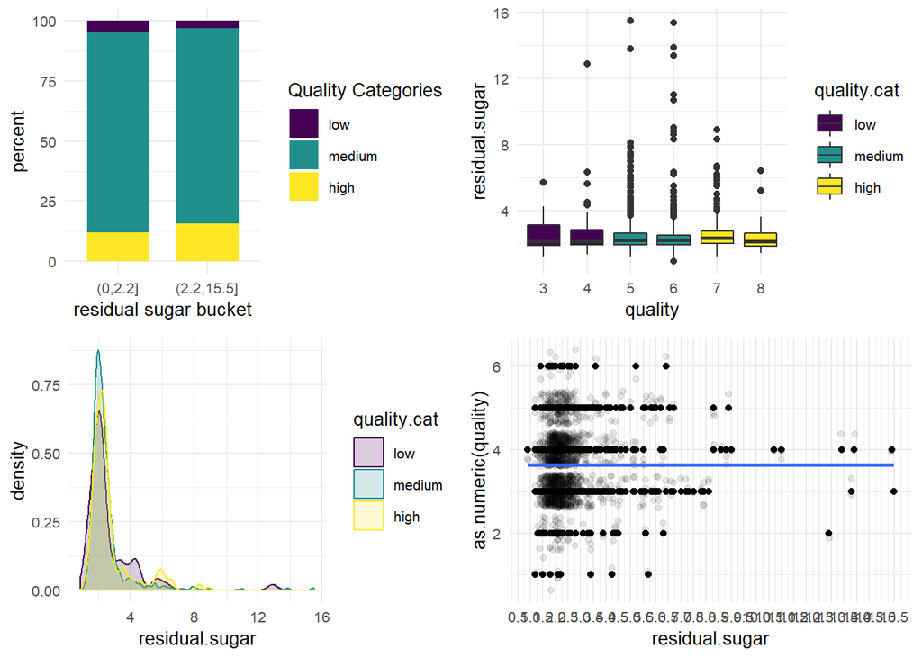

> The bar chart as well as the boxplot do not show a substantial difference between the quality rating categories dependent on the sugar content of the wine. Also the density and scatter plot do not reveal a substantial relationship. It seems that sweeter wines get a higher quality rating but there is only a very small difference.

### Alcohol and quality

```r
# Create a new variable by splitting alcohol into two categories (high and low) using min, median, max
summary(df$alcohol)
```

```
##    Min. 1st Qu.  Median    Mean 3rd Qu.    Max.
##    8.40    9.50   10.20   10.42   11.10   14.90
```

```r
# median = 10.20
df$alcohol.bucket <- cut(df$alcohol, c(8,10.20,14.90))
```

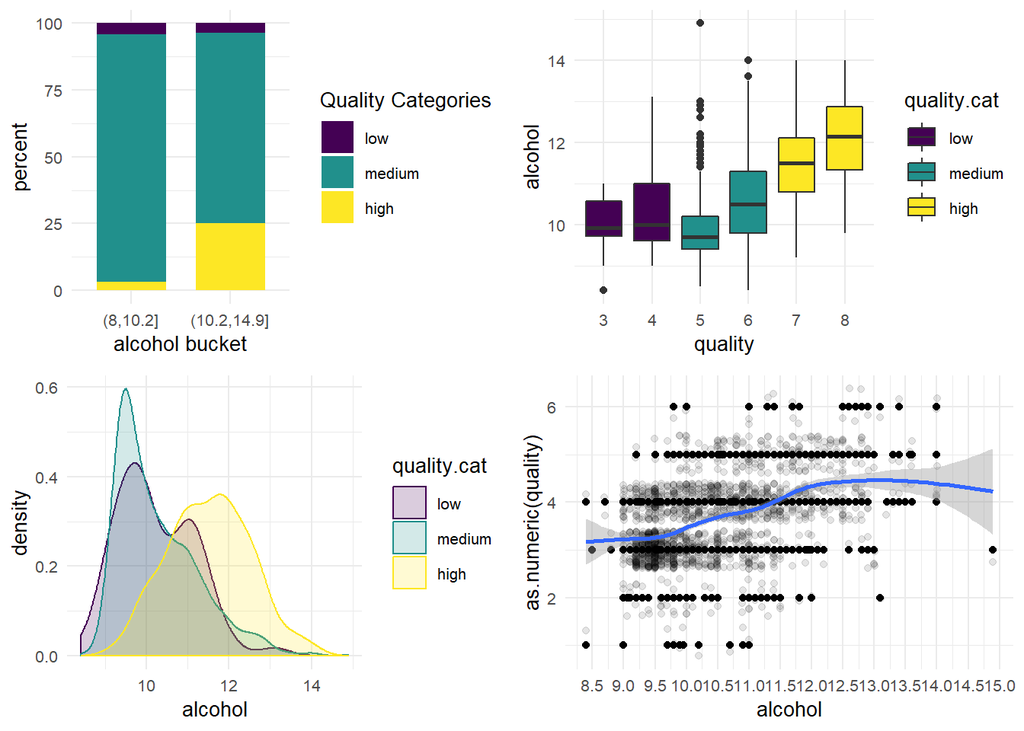

### Sulphates and quality

```r
# Create a new variable by splitting sulphates into two categories (high and low) using min, median, max
summary(df$sulphates)
```

```
##    Min. 1st Qu.  Median    Mean 3rd Qu.    Max.
##  0.3300  0.5500  0.6200  0.6581  0.7300  2.0000
```

```r
# median = 0.620
df$sulphates.bucket <- cut(df$sulphates, c(0,0.620,2.00))
```

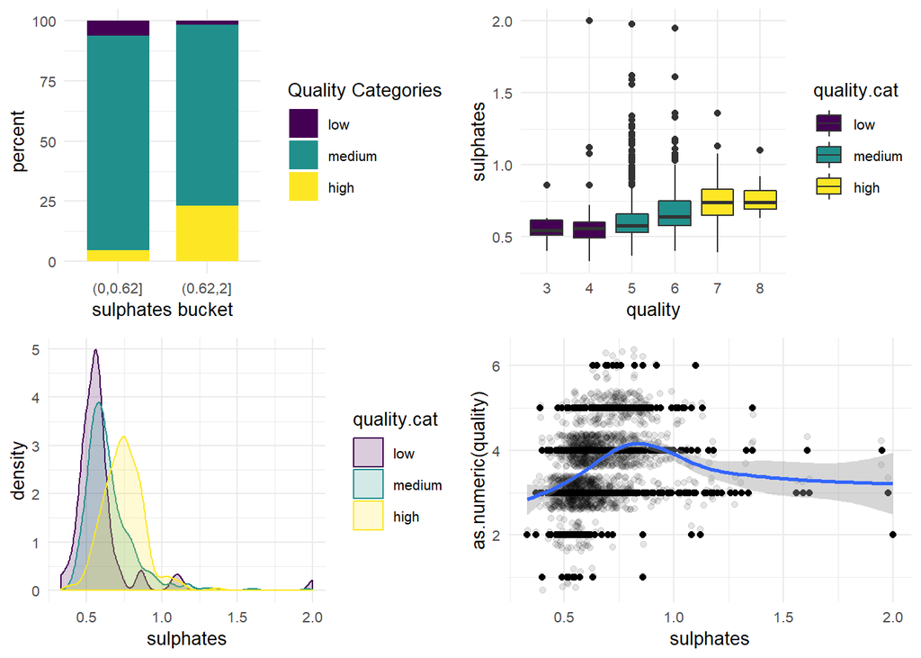

### pH and quality

```r
# Create a new variable by splitting pH into 4 categories (low, medium, moderate high and high) using min, 1st quantile, median, 3rd quantile and max
summary(df$pH)
```

```
##    Min. 1st Qu.  Median    Mean 3rd Qu.    Max.
##   2.740   3.210   3.310   3.311   3.400   4.010
```

```r
df$pH.bucket <- cut(df$pH, c(2.7,3.210,3.310,3.400,4.010))
```

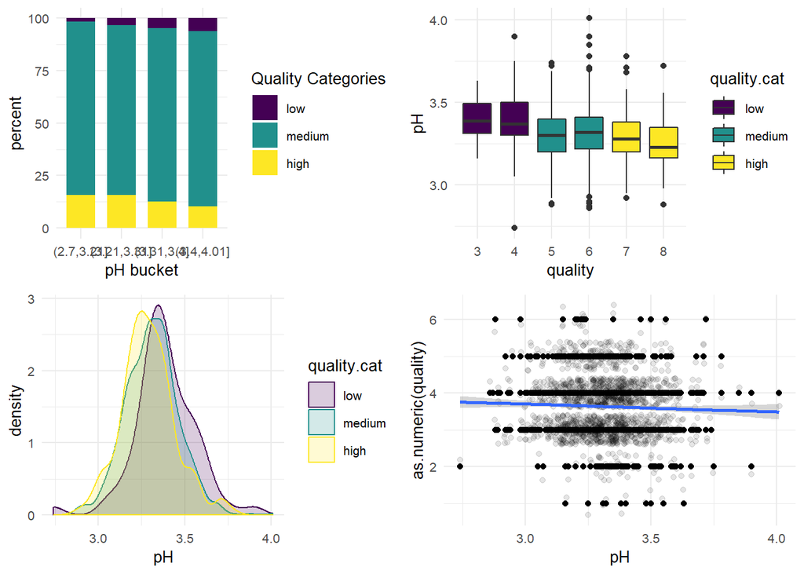

> There is a difference in the quality rating categories depending on the pH level. Wines with a high quality rating have a lower pH level than wines with a medium or low quality rating. But this difference does appear to be small. The scatter plot supports this assumption. There is a small negative relationship between the quality of a wine and its pH level.

### Density and quality

```r
# Create a new variable by splitting density into 4 categories (low, medium, moderate high and high) using min, 1st quantile, median, 3rd quantile and max

summary(df$density)
```

```
##    Min. 1st Qu.  Median    Mean 3rd Qu.    Max.
##  0.9901  0.9956  0.9968  0.9967  0.9978  1.0037
```

```r
df$density.bucket <- cut(df$density, c(0.9900,0.9956,0.9968,0.9978,1.0037))
```

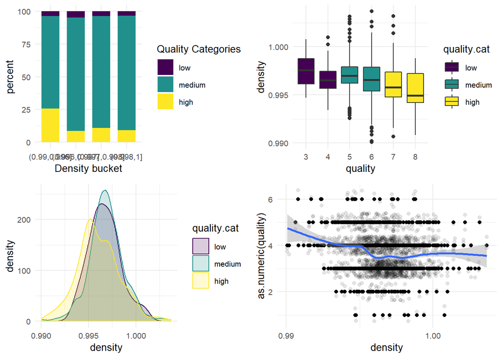

> Wines with a high quality rating have a lower density than wines with a low or medium quality rating. But this difference seems to be small. The scatter plot reveals that this relationship is not linear but a trend is visible.

Finally, I want to look at some scatter plots to explore the relationship between the properties: residual.sugar, alcohol, sulphates, pH and density according to the results of the correlation matrix above.

### Scatter plots - residual sugar

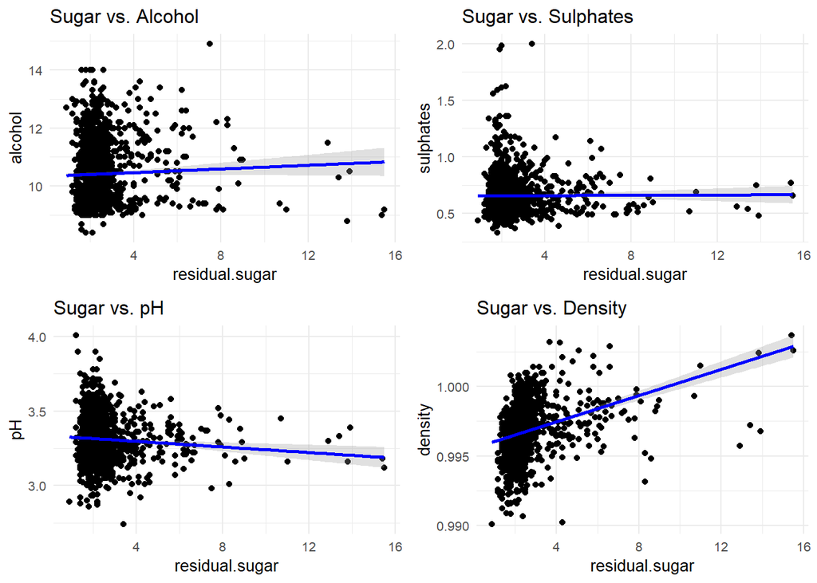

> There seems to be no substantial correlation between residual sugar and alcohol, sulphates and the pH level (although there is a weak negative correlation). Residual sugar correlates positive with the density of the wine. Additionally, I will compute pearson correlation coefficients.

```
##
##  Pearson's product-moment correlation
##
## data:  df$residual.sugar and df$alcohol
## t = 1.6829, df = 1597, p-value = 0.09258
## alternative hypothesis: true correlation is not equal to 0
## 95 percent confidence interval:
##  -0.006960058  0.090909069
## sample estimates:
##        cor
## 0.04207544
```

```
##
##  Pearson's product-moment correlation
##
## data:  df$residual.sugar and df$sulphates
## t = 0.22088, df = 1597, p-value = 0.8252
## alternative hypothesis: true correlation is not equal to 0
## 95 percent confidence interval:
##  -0.04350581  0.05453349
## sample estimates:
##         cor
## 0.005527121
```

```
##
##  Pearson's product-moment correlation
##
## data:  df$residual.sugar and df$pH
## t = -3.4355, df = 1597, p-value = 0.0006066
## alternative hypothesis: true correlation is not equal to 0
## 95 percent confidence interval:
##  -0.13411046 -0.03678574
## sample estimates:
##         cor
## -0.08565242
```

```
##
##  Pearson's product-moment correlation
##
## data:  df$residual.sugar and df$density
## t = 15.189, df = 1597, p-value < 2.2e-16
## alternative hypothesis: true correlation is not equal to 0
## 95 percent confidence interval:
##  0.3116908 0.3973835
## sample estimates:
##       cor
## 0.3552834
```

> The correlation coefficients support the observations above.

### Scatter plots - alcohol

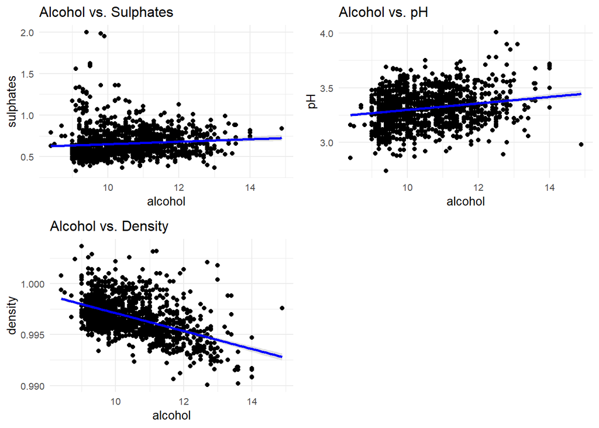

> Alcohol correlates negatively with density and positive with pH (although this correlation seems to be weak). There is not a substantial correlation between sulphates and alcohol. Additionally, I will compute pearson correlation coefficients.

```
##
##  Pearson's product-moment correlation
##
## data:  df$alcohol and df$sulphates
## t = 3.7568, df = 1597, p-value = 0.0001783
## alternative hypothesis: true correlation is not equal to 0
## 95 percent confidence interval:
##  0.04477906 0.14196454
## sample estimates:
##        cor
## 0.09359475
```

```
##
##  Pearson's product-moment correlation
##
## data:  df$alcohol and df$pH
## t = 8.397, df = 1597, p-value < 2.2e-16
## alternative hypothesis: true correlation is not equal to 0
## 95 percent confidence interval:
##  0.1582061 0.2521123
## sample estimates:
##       cor
## 0.2056325
```

```
##
##  Pearson's product-moment correlation
##
## data:  df$alcohol and df$density
## t = -22.838, df = 1597, p-value < 2.2e-16
## alternative hypothesis: true correlation is not equal to 0
## 95 percent confidence interval:
##  -0.5322547 -0.4583061
## sample estimates:
##        cor
## -0.4961798
```

> The correlation coefficients support the observations above.

### Scatter plots - sulphates

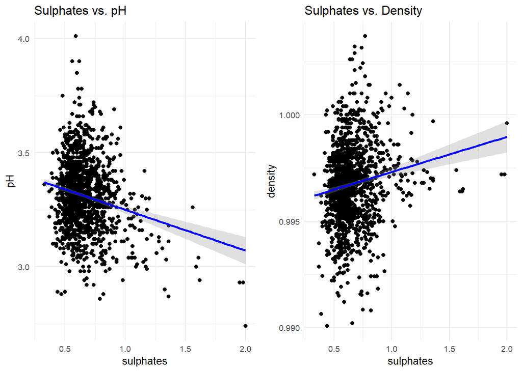

> Sulphates correlates positively with the density of the wine and negatively with the pH level of the wine. Both correlations seem to be weak. Additionally, I will compute pearson correlation coefficients.

```
##
##  Pearson's product-moment correlation
##
## data:  df$sulphates and df$pH
## t = -8.015, df = 1597, p-value = 2.107e-15
## alternative hypothesis: true correlation is not equal to 0
## 95 percent confidence interval:
##  -0.2433231 -0.1490634
## sample estimates:
##        cor
## -0.1966476
```

```
##
##  Pearson's product-moment correlation
##
## data:  df$sulphates and df$density
## t = 6.0012, df = 1597, p-value = 2.418e-09
## alternative hypothesis: true correlation is not equal to 0
## 95 percent confidence interval:
##  0.1002148 0.1961000
## sample estimates:
##       cor
## 0.1485064
```

> The correlation coefficients support the observations above.

### Scatter plot - pH and density

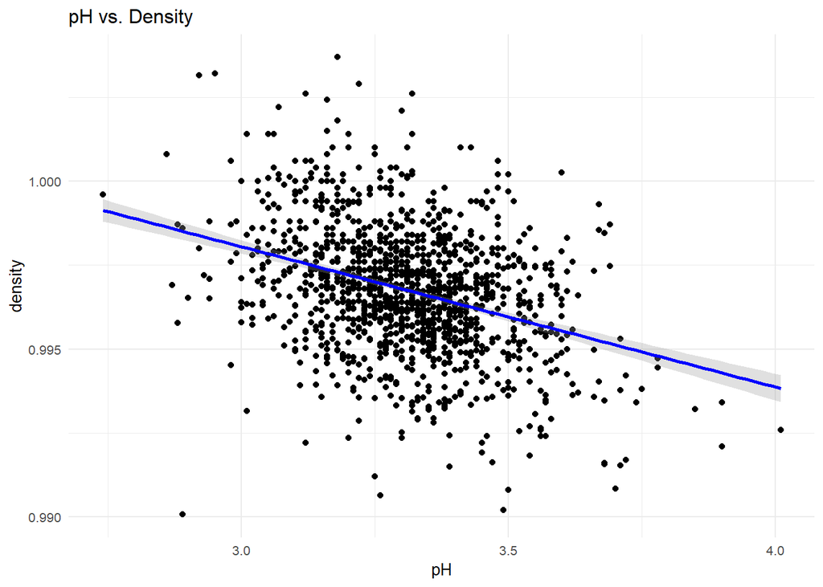

> There is a negative correlation between the pH level and the density. Additionally, I will compute pearson correlation coefficients.

```
##
##  Pearson's product-moment correlation
##
## data:  df$pH and df$density
## t = -14.53, df = 1597, p-value < 2.2e-16
## alternative hypothesis: true correlation is not equal to 0
## 95 percent confidence interval:
##  -0.3842835 -0.2976642
## sample estimates:
##        cor
## -0.3416993
```

> The correlation coefficient supports the observation above.

## Bivariate Analysis

### Did you observe any interesting relationships between the other features (not the main feature(s) of interest)?

> As the correlation matrix implies there are some strong relationships between the different acidity properties. There are some strong positive relationships between: fixed.acidity and citric.acid, free.sulfur.dioxide and total.sulfur.dioxide, as well as some strong to moderate negative relationships between: volatile.acidity and citric.acid.

## Multivariate Plots Section

Finally, I want to look at more complex interactions between some properties. As I found in the last section, the alcohol content, the pH level, the sulphate content as well as the density might influence the quality of red wines. Furthermore, relationships between these properties were explored, such as a negative correlation between the alcohol content and the density. In the next steps I will connect these findings an explore their interactions on the wine quality.

### Interaction density X alcohol

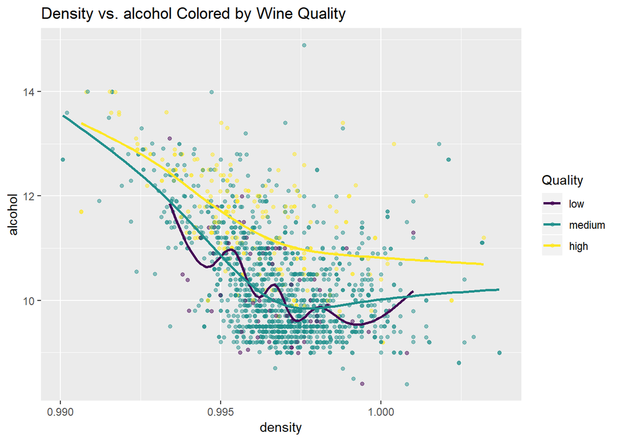

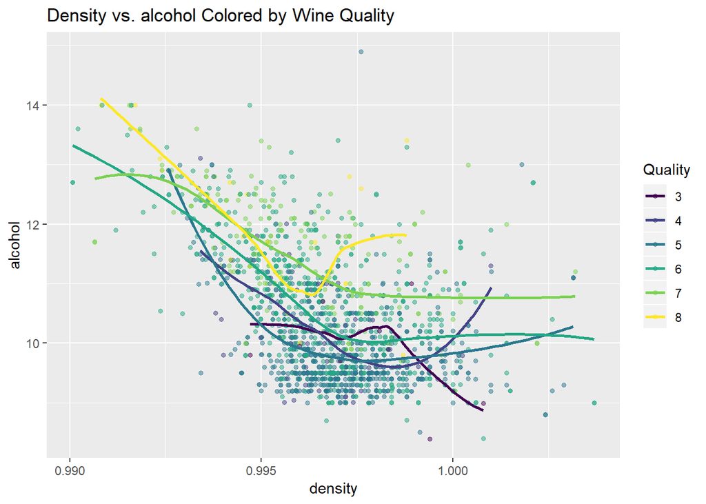

> Overall, high quality wines (7-8) have a higher alcohol content compared to medium or low quality wines. It is not easy to make an assumption for density but high and medium quality wines both have a higher variance compared to low quality wines which are located in the midth of the scale.

### Interaction density X pH

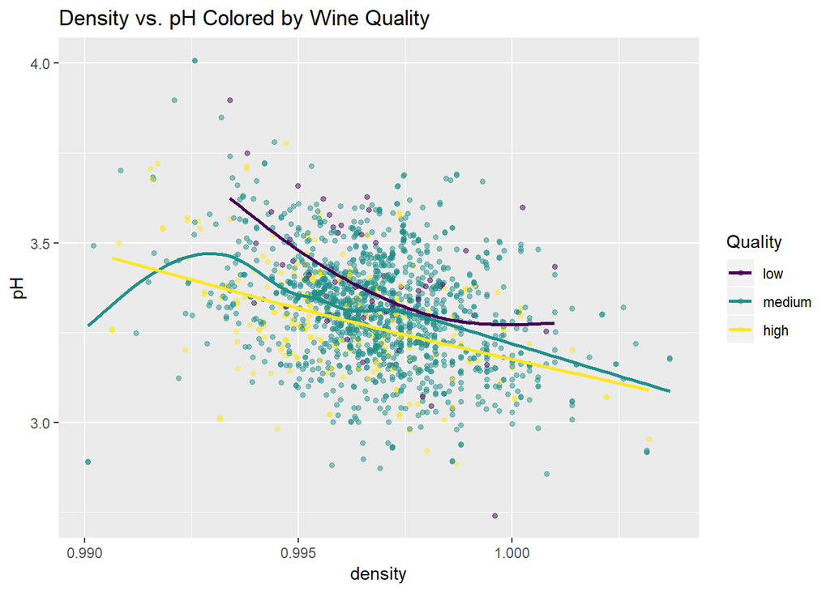

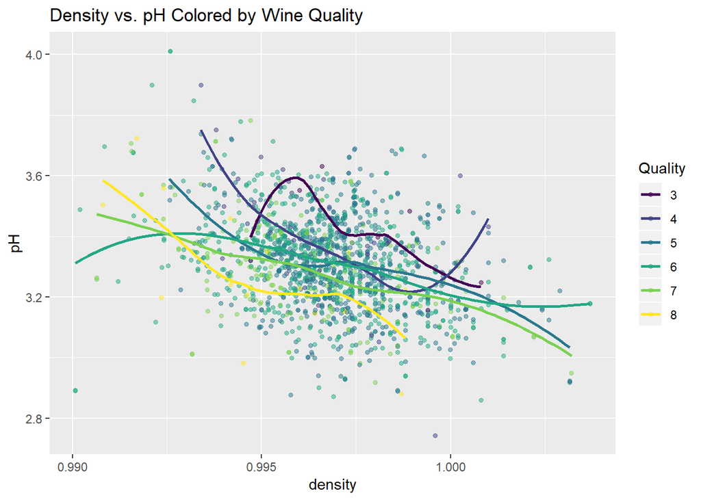

> High quality wines (7-8) have a lower pH level compared to medium or low quality wines. It is not easy to make an assumption for density but high and medium quality wines both have a higher variance compared to low quality wines which are located in the midth of the scale.

### Interaction alcohol X pH

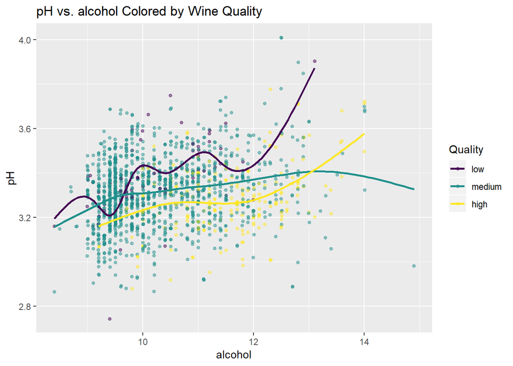

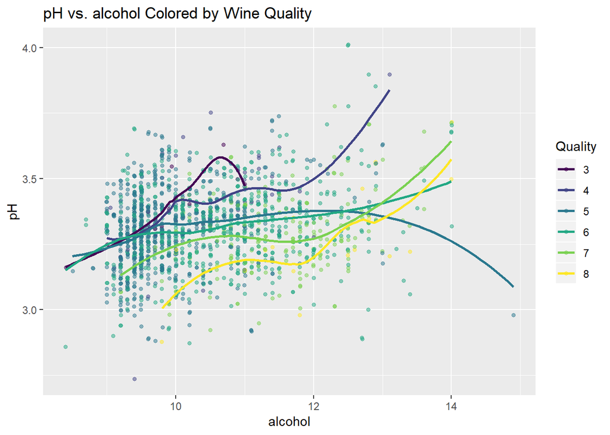

### Interaction sulphates X pH

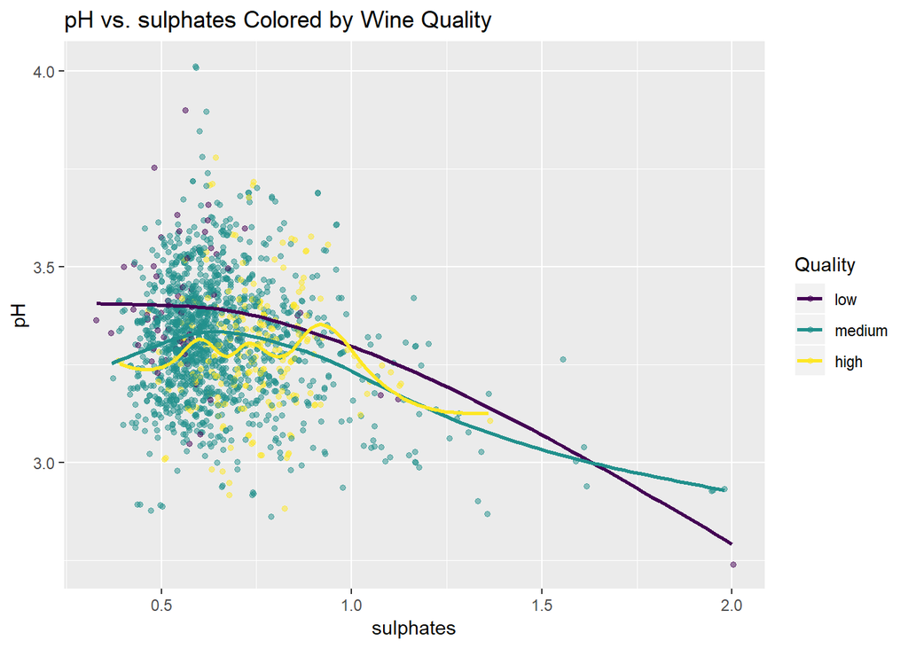

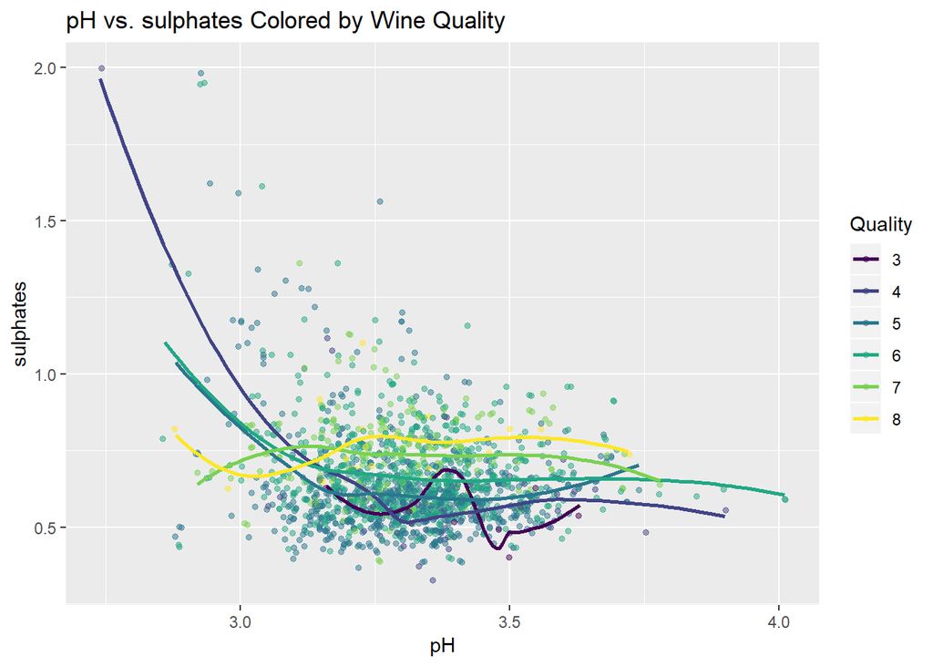

> High quality wines (7-8) have a higher sulphates content and a lower pH level compared to medium or low quality wines. But there a some low quality wines with an even higher sulpahtes concentration as well as high quality wines with higher pH levels.